# What Loans should be Approved or Declined

## by Ovie Iboyitie

## Investigation Overview

Of 113,937 loan listings, 49.65% are current, 33.42% of the loans are completed, 10.53% and 4.40% are chargedoff and defaulted respectively with 1.81% percent past due with less than 0.2% accounting for Cancelled and Final Payment in progress listings. Giving out loans could be for a lot of different reasons - improving the socioeconomic life of the borrower, saving the life of the borrower, imporiving the economy of a state by funding business and investments, but sometimes, or rather most of the times, its to make profit and/or a combo of making profits and other reasons.

## Dataset Overview

This data set contains 113,937 loans with 81 variables on each loan, including loan amount, borrower rate (or interest rate), current loan status, borrower income, and many others.

## Count of Loan Status

Of 113,937 loan listings, Majority(49.65%) of the loans are current, 33.42% of the loans are completed, 10.53% and 4.40% are chargedoff and defaulted respectively with 1.81% percent Past due

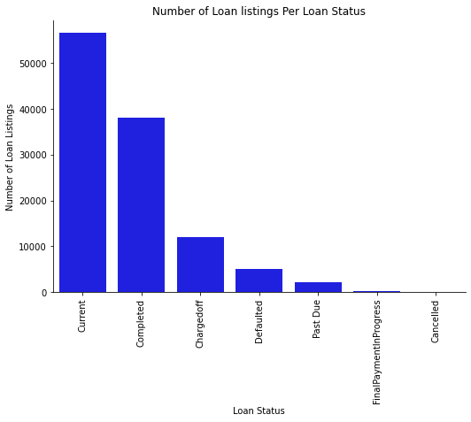

14.89% of the loans that had a listing category of "Not Avialable", a whooping 51.18% of the loans were listed for Debt Consolidation, 6.53% and 6.31% were listed as Home improvement and business respectively. The top 10 listings excluding the "Not available" category are

- Debt Consolidation
- Other
- Home Improvement
- Business
- Auto
- Personal Loan
- Household Expenses
- Medical/Dental
- Taxes
- Large Purchases

They account for 81.44% of the listed loans

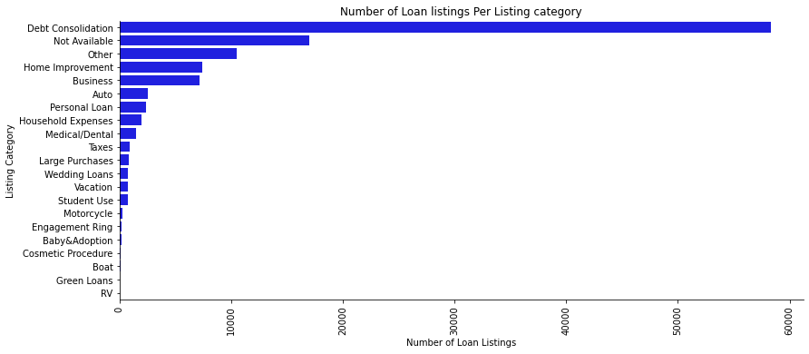

## Distribution of Monthly loan Payment and Loan Original Amount

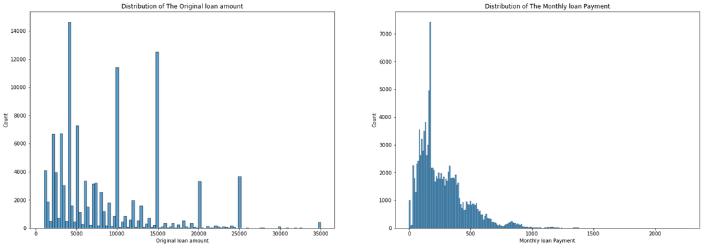

## Loan Term by Loan Status

1 year loans are good for business, but they only account for 1.42% of the loan listing. They have a whooping 94% completion rate. The Chargedoff 1 year loans have low stated monthly income. Only 66.8% of the 3 year loans were completed. Not high enough. 21.2% and 9.4% of the 3 year loans were Chargedoff and defaulted respectively. Now that's bad for business. but it doesn't just end there. 5 year loans are just as bad or worse. With a completion rate of only 55.3%. 24.8% and 15.6% of these loans are charged off and Past due resepctively. 4.3% of the loans are also defaulted. Is there something responsible for thes. Is there someting the can be done to turn this over?

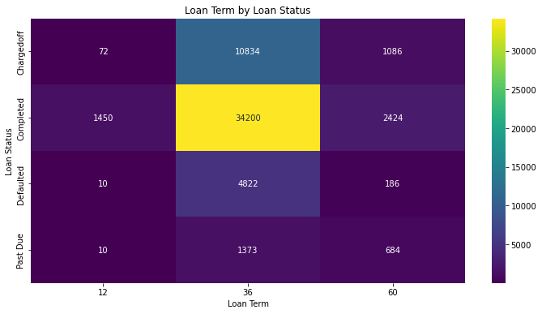

## Employment Status by Loan Status

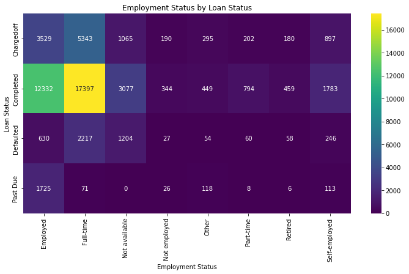

## Loan Original Amount and Monthly Loan Payment by Loan Status

Defaulted Loans and Past due loans had relatively lower StatedMonthlyIncome and a higher DebtToIncomeRatio and compromised majorly of 3 year loans. Completed Loans have a lower DebtToIncomeRatio and higher StatedMonthlyIncome. Defaulted and charged off loans have lower stated monthly income and relatively a larger pecentage of low Loan original amount as opposed to Completed and Current loans

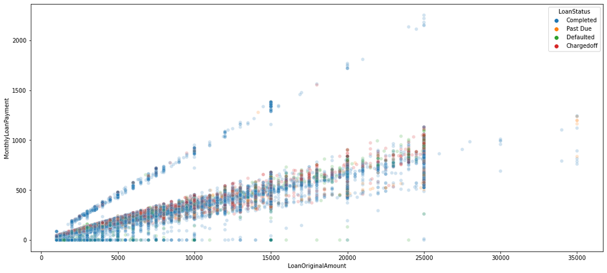